# Data Profiling Report

### Basic Statistics

#### Raw Counts

| Name | Value |
| --- | --- |
| Rows | 6,362,620 |
| Columns | 11 |
| Discrete columns | 3 |
| Continuous columns | 8 |
| All missing columns | 0 |
| Missing observations | 0 |
| Complete Rows | 6,362,620 |
| Total observations | 69,988,820 |
| Memory allocation | 1015.1 Mb |

#### Percentages

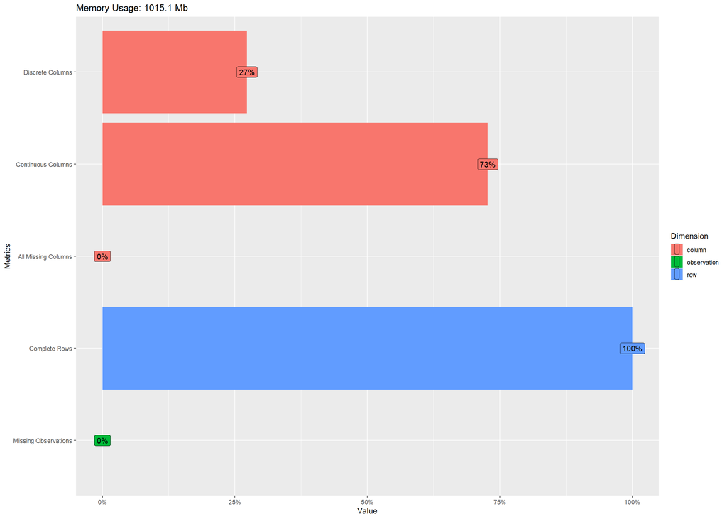

### Data Structure

[interactive chart not shown]

### Missing Data Profile

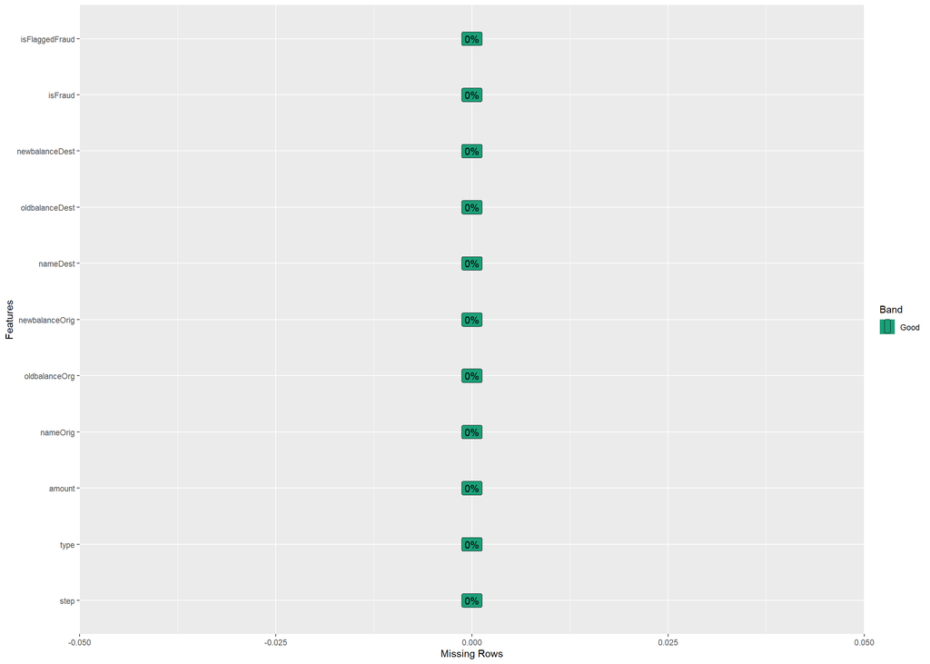

### Univariate Distribution

#### Histogram

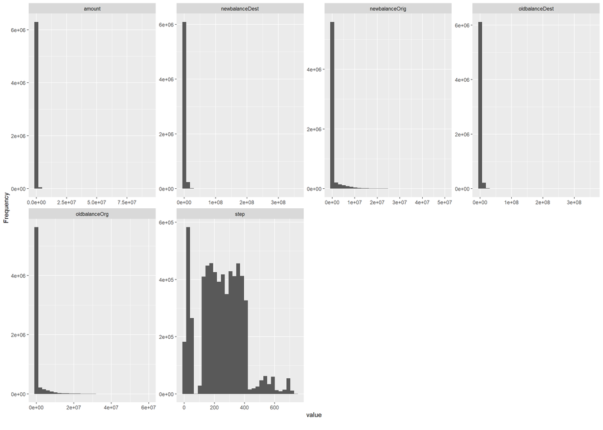

#### Bar Chart (with frequency)

```
## 2 columns ignored with more than 50 categories.
## nameOrig: 6353307 categories
## nameDest: 2722362 categories
```

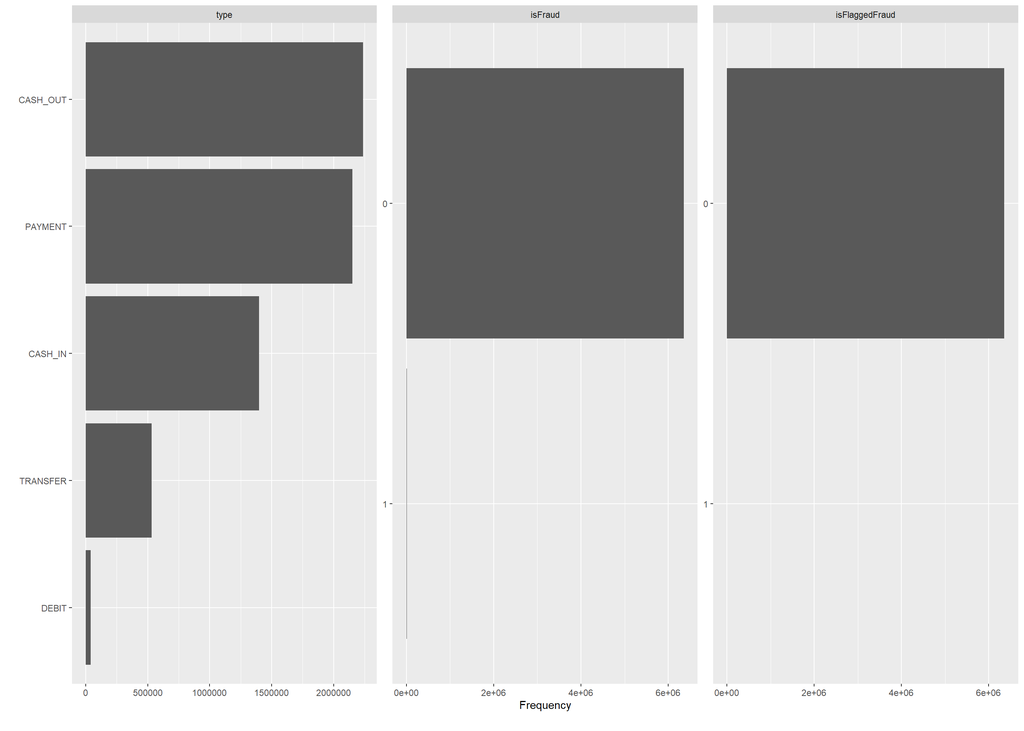

#### QQ Plot

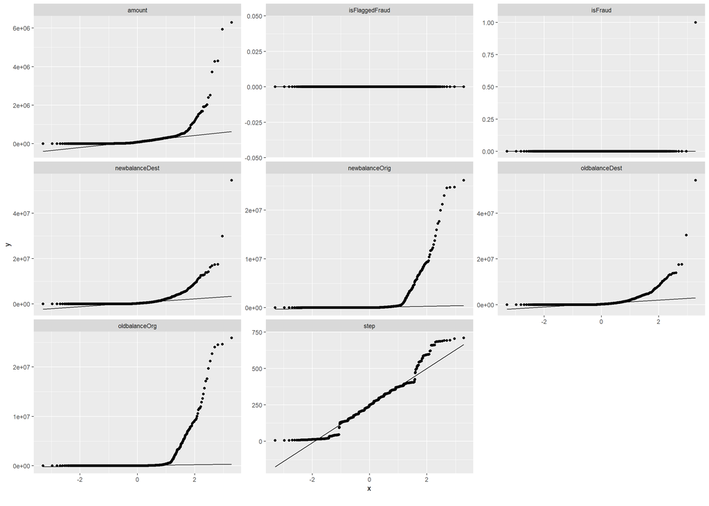